# Paso 2. Selección de variables y recorte de capas

M.en C. Viridiana Lizardo

6 de agosto de 2024

# Introducción.

Igual que en el anterior, pero para obtener las capas recortadas en el formato adecuado.

# Paquetes necesarios

```r
library(tidyverse)
library(sf)
library(tmap)
library(tmaptools)
```

## Datos raster

Para datos raster, como los de WorldClim, usamos `terra`. Este paquete reemplaza el paquete `raster` y hacer todo más rápido.

Más info aquí: [terra](https://rspatial.github.io/terra/, [Geocomputation with R](https://r.geocompx.org/raster-vector)

```r
library(terra)
```

## Obtención de datos Geográficos

El paquete `geodata` proporciona acceso a datos geográficos.

Más info aquí: [geodata](https://cran.r-project.org/web/packages/geodata/index.html)

Algunos de los datos que se pueden obtener con este paquete son:

| Function | Description |
| --- | --- |
| `cmip6_world`, `cmip6_tile` | Downscaled and calibrated CMIP6 projected future climate data |
| `elevation_3s`, `elevation_30s`, `elevation_global` | Elevation data |
| `gadm`, `world` | Administrative boundaries for any country, or the entire world from [GADM](https://gadm.org) |
| `landcover` | Landcover data derived from ESA WorldCover |
| `soil_world` | Global soils data from [SoilGrids](https://www.isric.org/explore/soilgrids) |
| `worldclim_global`, `worldclim_country`, `worldclim_tile` | [WorldClim](https://worldclim.org) glocal climate data |

```r
library(geodata)

wc <- worldclim_global(var = 'bio', #bioclim
                 res = 10, # puede ser 10, 5, 2.5, and 0.5 (minutes of a degree)
                 path = tempdir()) # en la carpeta temporal
```

```
probando la URL 'https://geodata.ucdavis.edu/climate/worldclim/2_1/base/wc2.1_10m_bio.zip'
```

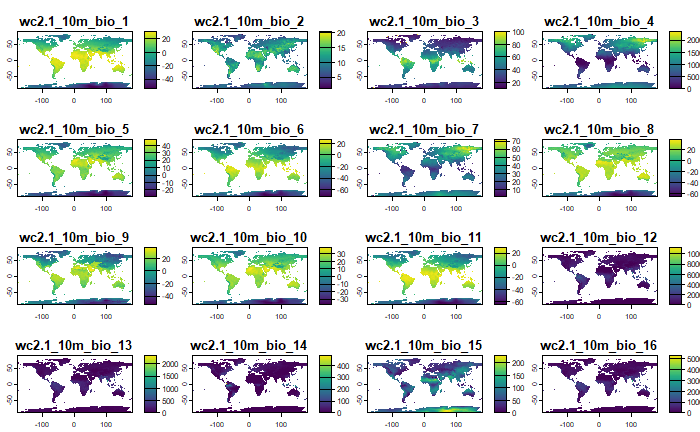

```r
plot(wc)
```

## Pre-procesado de datos

### Capas ambientales

La selección de variables ambientales se hace con la función [VIF](https://es.wikipedia.org/wiki/Factor_de_inflaci%C3%B3n_de_la_varianza) presente en el paquete `usdm` (Uncertainty and Sensitivity Analysis for Spatial Models). Este paquete proporciona herramientas para el análisis de incertidumbre y sensibilidad en modelos espaciales.

> Naimi B, Hamm Na, Groen TA, Skidmore AK, Toxopeus AG (2014). “Where is positional uncertainty a problem for species distribution modelling.” *Ecography*, **37**, 191-203. [doi:10.1111/j.1600-0587.2013.00205.x](https://doi.org/10.1111/j.1600-0587.2013.00205.x).

```r
library(usdm)
```

# Recortar capas

En este ejemplo se usarán países para simplificar todo. Se obtiene de los datos pregargados de R llamados `World` y seleccionaremos los países con registros de *D. virginiana*.

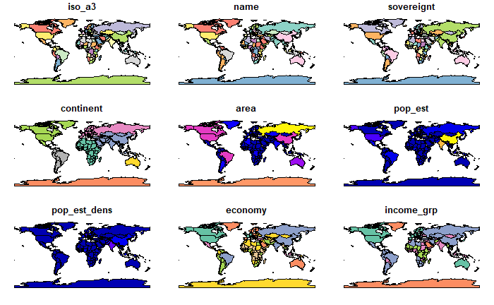

```r
data('World')
plot(World)
```

## Cargar datos limpios

```r
sf_occ<- list.files('data',
                    full.names = T, pattern = '.csv') %>% #listar todos los archivos csv
  lapply(., read.csv) %>% # cargarlos
  bind_rows() %>% # concatenarlos
   st_as_sf(coords = c('decimalLongitude', 'decimalLatitude'), # hacer espacial
         crs = 4326)
```

## Búsqueda espacial

Se usa la función `st_join` que hace una unión espacial y quitamos aquellos polígonos que no fueron unidos a los puntos.

```r
training_area <- st_join(World, sf_occ) %>%
  na.omit() %>%
  tally() # fusionar
```

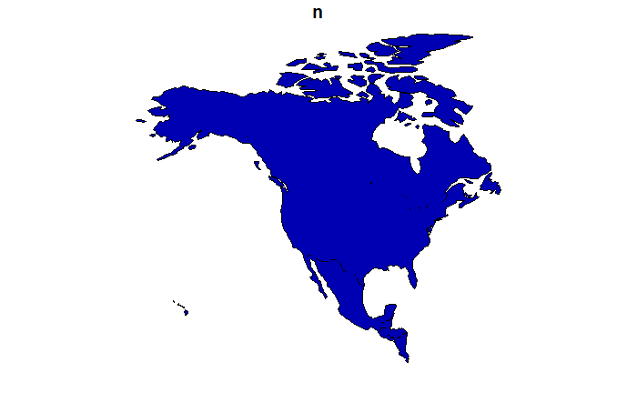

```r
plot(training_area)
```

## Cortar las capas raster

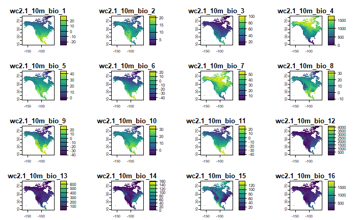

```r
env <- crop(wc, training_area,
     mask = T)

plot(env)
```

# Reducir variables con VIF

Lo ponemos en una bonita gráfica, cualquier variable mayor a 10 se considera problemática.

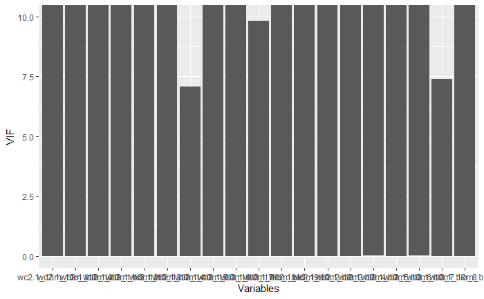

```r
vif(env) %>% ggplot(aes(x= Variables, y = VIF)) +
  geom_col() + coord_cartesian(ylim = c(0,10))
```

# Excluir con límite de coeficiente de correlación

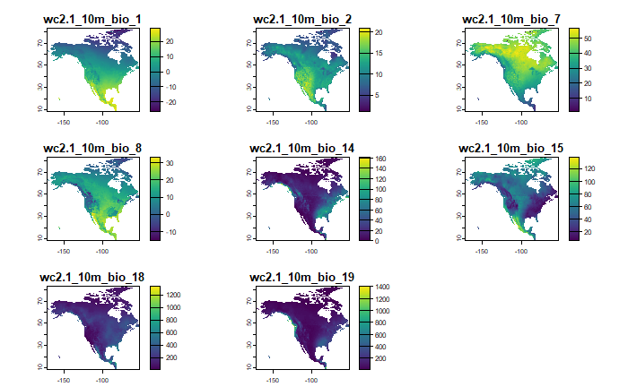

```r
vif_cor <- vifcor(env,th = 0.75,keep = 'wc2.1_10m_bio_1')
env_cor<- exclude(env, vif_cor)

plot(env_cor)
```

# Excluir con pasos

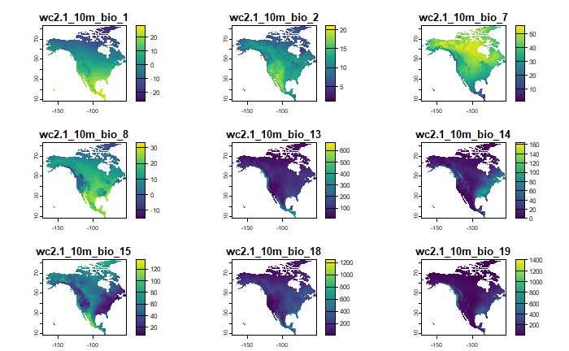

```r
vif_step <- vifstep(env,th = 10,keep = 'wc2.1_10m_bio_1')
env_step<- exclude(env, vif_step)

plot(env_step)
```

# Guardar el resultado

```r
# guardar un archivo por capa
writeRaster(env_cor,
            #guardar por capas
            filename = paste0(#'data/env/',
                              names(env_step), # nombrar cada capa
                              '.tif' ), overwrite =T)
```

[output not shown]